**FYP Final Version - LightGBM + RNN**

**Kaiyang Liu**

**2021/12/03**

# Packages Loading

```python
import re
import time
import os
import math
import pandas as pd
import numpy as np

# Preprocess
import spacy
from scipy.stats import entropy
import string
import nltk
nltk.download('stopwords')
from nltk.tokenize import word_tokenize
from nltk.corpus import stopwords
from nltk.stem import PorterStemmer
from nltk import FreqDist
nltk.download('punkt')
stop_words = set(stopwords.words('english'))
nltk.download('vader_lexicon')
from nltk.sentiment.vader import SentimentIntensityAnalyzer

# Gensim
import gensim
from gensim.models import LdaModel
from gensim import models, corpora, similarities
from gensim.models.word2vec import Word2Vec

# Sklearn
from sklearn.feature_extraction.text import CountVectorizer, TfidfVectorizer, TfidfTransformer
from sklearn.cluster import MiniBatchKMeans, KMeans
from sklearn.decomposition import PCA
from sklearn.metrics import homogeneity_score
from sklearn.metrics import silhouette_score
from sklearn.model_selection import cross_val_predict
from sklearn.model_selection import train_test_split
from sklearn.linear_model import LogisticRegression
from sklearn.metrics import log_loss, accuracy_score
from sklearn.svm import SVC
from sklearn.decomposition import TruncatedSVD
from sklearn.ensemble import RandomForestClassifier
from sklearn import preprocessing
from sklearn.preprocessing import LabelEncoder
import scikitplot.plotters as skplt

# Modeling
import lightgbm as lgb

# Viz
%matplotlib inline
import matplotlib.pyplot as plt
import seaborn as sns

# Sklearn
from sklearn.datasets import load_digits
from sklearn.model_selection import train_test_split
from sklearn.metrics import accuracy_score, precision_score, recall_score, f1_score, classification_report, confusion_matrix
from sklearn.preprocessing import label_binarize
from sklearn.metrics import roc_curve, auc
from sklearn.metrics import confusion_matrix

# Kears
from keras.preprocessing.sequence import pad_sequences
from keras.preprocessing.text import Tokenizer
from keras.utils import np_utils
from keras.layers.merge import concatenate
from keras.utils.np_utils import to_categorical
from keras.callbacks import ModelCheckpoint
from keras.models import load_model
from keras.optimizers import adam_v2

from keras import backend as K
import tensorflow.python.keras.engine
from tensorflow.python.keras.layers import Layer, InputSpec
from tensorflow.keras.layers import Layer, InputSpec
from keras import initializers, regularizers, constraints

# 搭建模型
from keras.models import Sequential, Model
from keras.layers import Dense, Embedding, Activation, Input
from keras.layers import Convolution1D, Flatten, Dropout, MaxPool1D
from keras.layers import  BatchNormalization
from keras.layers import Convolution1D, Conv1D,MaxPooling1D
from keras.layers import Dense, Embedding, Input, Lambda, Reshape
from keras.layers import Convolution1D, Flatten, Dropout, MaxPool1D, GlobalAveragePooling1D
from keras.layers import LSTM, GRU, TimeDistributed, Bidirectional
from keras.layers import Dense, Embedding, LSTM, GRU, Bidirectional, merge, Input, concatenate
from keras.layers.merge import Concatenate
```

# Data Exploration

## Loading Data

```python
train_variants_df = pd.read_csv("training_variants.csv")
train_text_df = pd.read_csv("training_text.zip",sep="\|\|",engine="python",names=["ID","Text"],skiprows=1)
test_variants_df = pd.read_csv("stage2_test_variants.csv")
test_text_df = pd.read_csv("stage2_test_text.csv",sep="\|\|",engine="python",names=["ID","Text"],skiprows=1)
```

```python
val_variants_df = pd.read_csv("test_variants.csv")
val_text_df = pd.read_csv("test_text.zip",sep="\|\|",engine="python",names=["ID","Text"],skiprows=1)
val_labels_df = pd.read_csv("stage1_solution_filtered.csv")
val_labels_df['Class'] = pd.to_numeric(val_labels_df.drop('ID', axis=1).idxmax(axis=1).str[5:])
val_labels_df = val_labels_df[['ID', 'Class']]
val_text_df = pd.merge(val_text_df, val_labels_df, how='left', on='ID')
```

```python
print("Train Variant".ljust(15), train_variants_df.shape)
print("Train Text".ljust(15), train_text_df.shape)
print("Test Variant".ljust(15), test_variants_df.shape)
print("Test Text".ljust(15), test_text_df.shape)
print("Validation Variant".ljust(15), val_variants_df.shape)
print("Validation Text".ljust(15), val_text_df.shape)
```

```
Train Variant   (3321, 4)
Train Text      (3321, 2)
Test Variant    (986, 3)
Test Text       (986, 2)
Validation Variant (5668, 3)
Validation Text (5668, 3)
```

```python
train_variants_df.head()
```

|  | ID | Gene | Variation | Class |
| --- | --- | --- | --- | --- |
| 0 | 0 | FAM58A | Truncating Mutations | 1 |
| 1 | 1 | CBL | W802* | 2 |
| 2 | 2 | CBL | Q249E | 2 |
| 3 | 3 | CBL | N454D | 3 |
| 4 | 4 | CBL | L399V | 4 |

```python
test_variants_df.head()
```

|  | ID | Gene | Variation |
| --- | --- | --- | --- |
| 0 | 1 | CHEK2 | H371Y |
| 1 | 2 | AXIN2 | Truncating Mutations |
| 2 | 3 | WNT4 | E216G |
| 3 | 4 | SUCLA2 | G118R |
| 4 | 5 | BRAF | T599insTT |

```python
val_variants_df.head()
```

|  | ID | Gene | Variation |
| --- | --- | --- | --- |
| 0 | 0 | ACSL4 | R570S |
| 1 | 1 | NAGLU | P521L |
| 2 | 2 | PAH | L333F |
| 3 | 3 | ING1 | A148D |
| 4 | 4 | TMEM216 | G77A |

```python
train_variants_df['Class'].value_counts()
```

```
7    953
4    686
1    568
2    452
6    275
5    242
3     89
9     37
8     19
Name: Class, dtype: int64
```

```python
train_text_df
```

|  | ID | Text |
| --- | --- | --- |
| 0 | 0 | Cyclin-dependent kinases (CDKs) regulate a var... |
| 1 | 1 | Abstract Background Non-small cell lung canc... |
| 2 | 2 | Abstract Background Non-small cell lung canc... |
| 3 | 3 | Recent evidence has demonstrated that acquired... |
| 4 | 4 | Oncogenic mutations in the monomeric Casitas B... |
| ... | ... | ... |
| 3316 | 3316 | Introduction Myelodysplastic syndromes (MDS) ... |
| 3317 | 3317 | Introduction Myelodysplastic syndromes (MDS) ... |
| 3318 | 3318 | The Runt-related transcription factor 1 gene (... |
| 3319 | 3319 | The RUNX1/AML1 gene is the most frequent targe... |
| 3320 | 3320 | The most frequent mutations associated with le... |

3321 rows × 2 columns

```python
test_text_df
```

|  | ID | Text |
| --- | --- | --- |
| 0 | 1 | The incidence of breast cancer is increasing i... |
| 1 | 2 | An unselected series of 310 colorectal carcino... |
| 2 | 3 | Mycosis fungoides and Sézary syndrome are prim... |
| 3 | 4 | Regulated progression through the cell cycle ... |
| 4 | 5 | Pilocytic astrocytoma (PA) is emerging as a tu... |
| ... | ... | ... |
| 981 | 982 | IκB kinase β (IKKβ) is involved in tumor devel... |
| 982 | 983 | he identification of subtype-specific transloc... |
| 983 | 984 | Cardio-facio-cutaneous (CFC) syndrome (MIM 115... |
| 984 | 985 | Screening for tumor suppressor genes in breast... |
| 985 | 986 | Histiocytic neoplasms are clonal, hematopoieti... |

986 rows × 2 columns

```python
val_text_df
```

|  | ID | Text | Class |
| --- | --- | --- | --- |
| 0 | 0 | 2. This mutation resulted in a myeloproliferat... | NaN |
| 1 | 1 | Abstract The Large Tumor Suppressor 1 (LATS1)... | NaN |
| 2 | 2 | Vascular endothelial growth factor receptor (V... | NaN |
| 3 | 3 | Inflammatory myofibroblastic tumor (IMT) is a ... | NaN |
| 4 | 4 | Abstract Retinoblastoma is a pediatric retina... | NaN |
| ... | ... | ... | ... |
| 5663 | 5663 | The realization in the late 1970s that RAS har... | NaN |
| 5664 | 5664 | Hemizygous deletions are common molecular abno... | NaN |
| 5665 | 5665 | All most R267W of has with to SMARTpool invest... | NaN |
| 5666 | 5666 | Abstract Blood samples from 125 unrelated fami... | NaN |
| 5667 | 5667 | Loss of DNA mismatch repair (MMR) in humans, m... | NaN |

5668 rows × 3 columns

## Distribution of genetic mutation classes

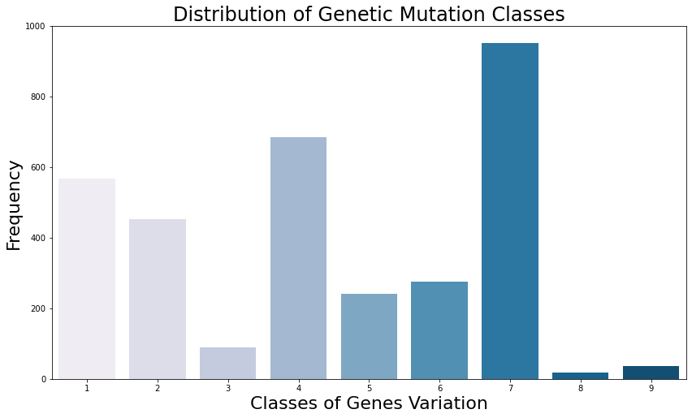

```python
plt.figure(figsize=(14,8))
sns.countplot(x="Class", data=train_variants_df, palette="PuBu")
plt.ylabel('Frequency', fontsize=22)
plt.xlabel('Classes of Genes Variation', fontsize=22)
plt.title("Distribution of Genetic Mutation Classes", fontsize=24)
plt.show()
```

```python
gene_group = train_variants_df.groupby("Gene")['Gene'].count()
minimal_occ_genes = gene_group.sort_values(ascending=True)[:10]
print("Genes with maximal occurences\n", gene_group.sort_values(ascending=False)[:10])
print("\nGenes with minimal occurences\n", minimal_occ_genes)
```

```
Genes with maximal occurences
 Gene
BRCA1     264
TP53      163
EGFR      141
PTEN      126
BRCA2     125
KIT        99
BRAF       93
ALK        69
ERBB2      69
PDGFRA     60
Name: Gene, dtype: int64

Genes with minimal occurences
 Gene
KLF4      1
FGF19     1
FANCC     1
FAM58A    1
PAK1      1
ERRFI1    1
PAX8      1
PIK3R3    1
PMS1      1
PPM1D     1
Name: Gene, dtype: int64
```

## Distribution of Gene in Different Classes

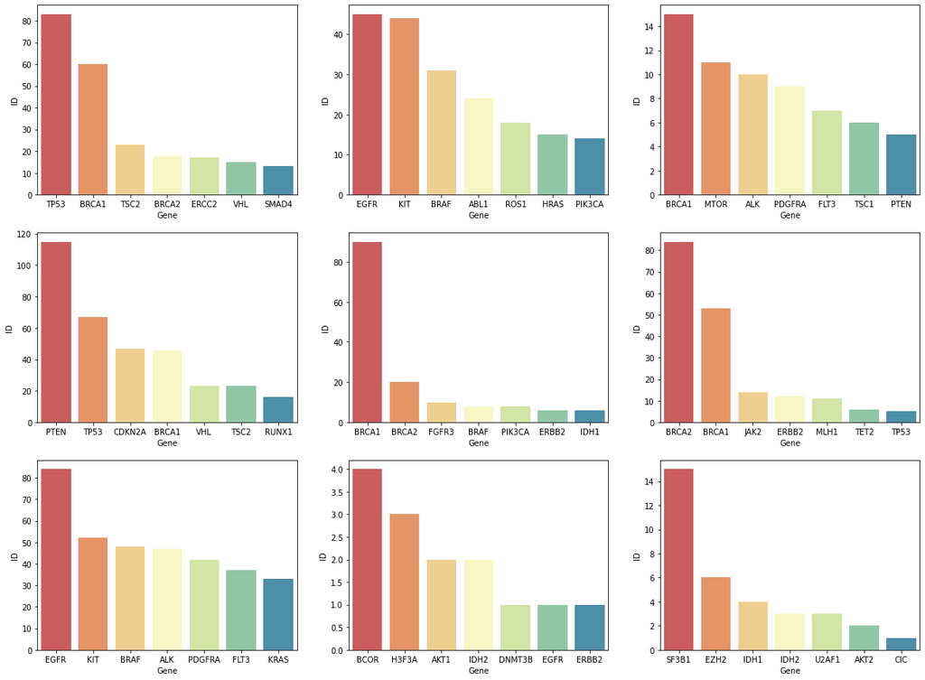

```python
fig, axs = plt.subplots(ncols=3, nrows=3, figsize=(20,15))

for i in range(3):
    for j in range(3):
        gene_count_grp = train_variants_df[train_variants_df["Class"]==((i*3+j)+1)].groupby('Gene')["ID"].count().reset_index()
        sorted_gene_group = gene_count_grp.sort_values('ID', ascending=False)
        sorted_gene_group_top_7 = sorted_gene_group[:7]
        sns.barplot(x="Gene", y="ID", data=sorted_gene_group_top_7, ax=axs[i][j],palette="Spectral")
```

Some points we can conclude from these graphs:

BRCA1 is highly dominating Class 5\ SF3B1 is highly dominating Class 9\ BRCA1 and BRCA2 are dominating Class 6

# Data Preprocessing

## Text Preprocessing

**Steps**\ **1. Tokenization**\ **2. Removal of punctuations**\ **3. Lemmatization (词形还原)***\ **4. Removal of stop words**\ **5. Lower casting**\ **6. Special consideration for clinical text***

```python
# Remove punctuation
train_text_df['Text_processed'] = train_text_df['Text'].map(lambda x: re.sub('[\',.!?*]', '', str(x)))
# Convert the titles to lowercase
train_text_df['Text_processed'] = train_text_df['Text_processed'].replace(r'\n',' ', regex=True)
train_text_df['Text_processed'] = train_text_df['Text_processed'].map(lambda x: x.lower())
# Print out the first rows of papers
train_text_df['Text_processed'] = train_text_df['Text_processed'].apply(lambda x: x.strip())
train_text_df
```

|  | ID | Text | Text_processed |
| --- | --- | --- | --- |
| 0 | 0 | Cyclin-dependent kinases (CDKs) regulate a var... | cyclin-dependent kinases (cdks) regulate a var... |
| 1 | 1 | Abstract Background Non-small cell lung canc... | abstract background non-small cell lung cance... |
| 2 | 2 | Abstract Background Non-small cell lung canc... | abstract background non-small cell lung cance... |
| 3 | 3 | Recent evidence has demonstrated that acquired... | recent evidence has demonstrated that acquired... |
| 4 | 4 | Oncogenic mutations in the monomeric Casitas B... | oncogenic mutations in the monomeric casitas b... |
| ... | ... | ... | ... |
| 3316 | 3316 | Introduction Myelodysplastic syndromes (MDS) ... | introduction myelodysplastic syndromes (mds) ... |
| 3317 | 3317 | Introduction Myelodysplastic syndromes (MDS) ... | introduction myelodysplastic syndromes (mds) ... |
| 3318 | 3318 | The Runt-related transcription factor 1 gene (... | the runt-related transcription factor 1 gene (... |
| 3319 | 3319 | The RUNX1/AML1 gene is the most frequent targe... | the runx1/aml1 gene is the most frequent targe... |
| 3320 | 3320 | The most frequent mutations associated with le... | the most frequent mutations associated with le... |

3321 rows × 3 columns

```python
# Remove punctuation
test_text_df['Text_processed'] = test_text_df['Text'].map(lambda x: re.sub('[\',.!?*]', '', str(x)))
# Convert the titles to lowercase
test_text_df['Text_processed'] = test_text_df['Text_processed'].replace(r'\n',' ', regex=True)
test_text_df['Text_processed'] = test_text_df['Text_processed'].map(lambda x: x.lower())
# Print out the first rows of papers
test_text_df['Text_processed'] = test_text_df['Text_processed'].apply(lambda x: x.strip())
test_text_df
```

|  | ID | Text | Text_processed |
| --- | --- | --- | --- |
| 0 | 1 | The incidence of breast cancer is increasing i... | the incidence of breast cancer is increasing i... |
| 1 | 2 | An unselected series of 310 colorectal carcino... | an unselected series of 310 colorectal carcino... |
| 2 | 3 | Mycosis fungoides and Sézary syndrome are prim... | mycosis fungoides and sézary syndrome are prim... |
| 3 | 4 | Regulated progression through the cell cycle ... | regulated progression through the cell cycle r... |
| 4 | 5 | Pilocytic astrocytoma (PA) is emerging as a tu... | pilocytic astrocytoma (pa) is emerging as a tu... |
| ... | ... | ... | ... |
| 981 | 982 | IκB kinase β (IKKβ) is involved in tumor devel... | iκb kinase β (ikkβ) is involved in tumor devel... |
| 982 | 983 | he identification of subtype-specific transloc... | he identification of subtype-specific transloc... |
| 983 | 984 | Cardio-facio-cutaneous (CFC) syndrome (MIM 115... | cardio-facio-cutaneous (cfc) syndrome (mim 115... |
| 984 | 985 | Screening for tumor suppressor genes in breast... | screening for tumor suppressor genes in breast... |
| 985 | 986 | Histiocytic neoplasms are clonal, hematopoieti... | histiocytic neoplasms are clonal hematopoietic... |

986 rows × 3 columns

```python
# Remove punctuation
val_text_df['Text_processed'] = val_text_df['Text'].map(lambda x: re.sub('[\',.!?*]', '', str(x)))
# Convert the titles to lowercase
val_text_df['Text_processed'] = val_text_df['Text_processed'].replace(r'\n',' ', regex=True)
val_text_df['Text_processed'] = val_text_df['Text_processed'].map(lambda x: x.lower())
# Print out the first rows of papers
val_text_df['Text_processed'] = val_text_df['Text_processed'].apply(lambda x: x.strip())
val_text_df
```

|  | ID | Text | Class | Text_processed |
| --- | --- | --- | --- | --- |
| 0 | 0 | 2. This mutation resulted in a myeloproliferat... | NaN | 2 this mutation resulted in a myeloproliferati... |
| 1 | 1 | Abstract The Large Tumor Suppressor 1 (LATS1)... | NaN | abstract the large tumor suppressor 1 (lats1) ... |
| 2 | 2 | Vascular endothelial growth factor receptor (V... | NaN | vascular endothelial growth factor receptor (v... |
| 3 | 3 | Inflammatory myofibroblastic tumor (IMT) is a ... | NaN | inflammatory myofibroblastic tumor (imt) is a ... |
| 4 | 4 | Abstract Retinoblastoma is a pediatric retina... | NaN | abstract retinoblastoma is a pediatric retinal... |
| ... | ... | ... | ... | ... |
| 5663 | 5663 | The realization in the late 1970s that RAS har... | NaN | the realization in the late 1970s that ras har... |
| 5664 | 5664 | Hemizygous deletions are common molecular abno... | NaN | hemizygous deletions are common molecular abno... |
| 5665 | 5665 | All most R267W of has with to SMARTpool invest... | NaN | all most r267w of has with to smartpool invest... |
| 5666 | 5666 | Abstract Blood samples from 125 unrelated fami... | NaN | abstract blood samples from 125 unrelated fami... |
| 5667 | 5667 | Loss of DNA mismatch repair (MMR) in humans, m... | NaN | loss of dna mismatch repair (mmr) in humans ma... |

5668 rows × 4 columns

```python
train_full = train_variants_df.merge(train_text_df, how="inner", left_on="ID", right_on="ID")
train_full = train_full.drop("Text", axis=1)
train_full.head()
```

|  | ID | Gene | Variation | Class | Text_processed |
| --- | --- | --- | --- | --- | --- |
| 0 | 0 | FAM58A | Truncating Mutations | 1 | cyclin-dependent kinases (cdks) regulate a var... |
| 1 | 1 | CBL | W802* | 2 | abstract background non-small cell lung cance... |
| 2 | 2 | CBL | Q249E | 2 | abstract background non-small cell lung cance... |
| 3 | 3 | CBL | N454D | 3 | recent evidence has demonstrated that acquired... |
| 4 | 4 | CBL | L399V | 4 | oncogenic mutations in the monomeric casitas b... |

```python
test_full = test_variants_df.merge(test_text_df, how="inner", left_on="ID", right_on="ID")
test_full = test_full.drop("Text", axis=1)
test_full.head()
```

|  | ID | Gene | Variation | Text_processed |
| --- | --- | --- | --- | --- |
| 0 | 1 | CHEK2 | H371Y | the incidence of breast cancer is increasing i... |
| 1 | 2 | AXIN2 | Truncating Mutations | an unselected series of 310 colorectal carcino... |
| 2 | 3 | WNT4 | E216G | mycosis fungoides and sézary syndrome are prim... |
| 3 | 4 | SUCLA2 | G118R | regulated progression through the cell cycle r... |
| 4 | 5 | BRAF | T599insTT | pilocytic astrocytoma (pa) is emerging as a tu... |

```python
val_full = val_variants_df.merge(val_text_df, how="inner", left_on="ID", right_on="ID")
val_full = val_full.drop("Text", axis=1)
val_full.head()
```

|  | ID | Gene | Variation | Class | Text_processed |
| --- | --- | --- | --- | --- | --- |
| 0 | 0 | ACSL4 | R570S | NaN | 2 this mutation resulted in a myeloproliferati... |
| 1 | 1 | NAGLU | P521L | NaN | abstract the large tumor suppressor 1 (lats1) ... |
| 2 | 2 | PAH | L333F | NaN | vascular endothelial growth factor receptor (v... |
| 3 | 3 | ING1 | A148D | NaN | inflammatory myofibroblastic tumor (imt) is a ... |
| 4 | 4 | TMEM216 | G77A | NaN | abstract retinoblastoma is a pediatric retinal... |

```python
import nltk
nltk.download('words')
words = set(nltk.corpus.words.words())
train_full['Text_processed'] = train_full['Text_processed'].apply(lambda x: " ".join(w for w in nltk.wordpunct_tokenize(x) if w.lower() in words ))
test_full['Text_processed'] = test_full['Text_processed'].apply(lambda x: " ".join(w for w in nltk.wordpunct_tokenize(x) if w.lower() in words ))
val_full['Text_processed'] = val_full['Text_processed'].apply(lambda x: " ".join(w for w in nltk.wordpunct_tokenize(x) if w.lower() in words ))
```

## Word Statistics

```python
train_text_df.loc[:, 'Text_count']  = train_text_df["Text_processed"].apply(lambda x: len(x.split()))
train_text_df.head()
```

|  | ID | Text | Text_processed | Text_count |
| --- | --- | --- | --- | --- |
| 0 | 0 | Cyclin-dependent kinases (CDKs) regulate a var... | cyclin-dependent kinases (cdks) regulate a var... | 6089 |
| 1 | 1 | Abstract Background Non-small cell lung canc... | abstract background non-small cell lung cance... | 5756 |
| 2 | 2 | Abstract Background Non-small cell lung canc... | abstract background non-small cell lung cance... | 5756 |
| 3 | 3 | Recent evidence has demonstrated that acquired... | recent evidence has demonstrated that acquired... | 5571 |
| 4 | 4 | Oncogenic mutations in the monomeric Casitas B... | oncogenic mutations in the monomeric casitas b... | 6197 |

```python
test_text_df.loc[:, 'Text_count']  = test_text_df["Text_processed"].apply(lambda x: len(x.split()))
test_text_df.head()
```

|  | ID | Text | Text_processed | Text_count |
| --- | --- | --- | --- | --- |
| 0 | 1 | The incidence of breast cancer is increasing i... | the incidence of breast cancer is increasing i... | 5036 |
| 1 | 2 | An unselected series of 310 colorectal carcino... | an unselected series of 310 colorectal carcino... | 10241 |
| 2 | 3 | Mycosis fungoides and Sézary syndrome are prim... | mycosis fungoides and sézary syndrome are prim... | 8546 |
| 3 | 4 | Regulated progression through the cell cycle ... | regulated progression through the cell cycle r... | 6168 |
| 4 | 5 | Pilocytic astrocytoma (PA) is emerging as a tu... | pilocytic astrocytoma (pa) is emerging as a tu... | 3262 |

```python
val_text_df.loc[:, 'Text_count']  = val_text_df["Text_processed"].apply(lambda x: len(x.split()))
val_text_df.head()
```

|  | ID | Text | Class | Text_processed | Text_count |
| --- | --- | --- | --- | --- | --- |
| 0 | 0 | 2. This mutation resulted in a myeloproliferat... | NaN | 2 this mutation resulted in a myeloproliferati... | 7416 |
| 1 | 1 | Abstract The Large Tumor Suppressor 1 (LATS1)... | NaN | abstract the large tumor suppressor 1 (lats1) ... | 4709 |
| 2 | 2 | Vascular endothelial growth factor receptor (V... | NaN | vascular endothelial growth factor receptor (v... | 11072 |
| 3 | 3 | Inflammatory myofibroblastic tumor (IMT) is a ... | NaN | inflammatory myofibroblastic tumor (imt) is a ... | 8380 |
| 4 | 4 | Abstract Retinoblastoma is a pediatric retina... | NaN | abstract retinoblastoma is a pediatric retinal... | 11159 |

```python
train_full = train_variants_df.merge(train_text_df, how="inner", left_on="ID", right_on="ID")
train_full.head()
```

|  | ID | Gene | Variation | Class | Text | Text_processed | Text_count |
| --- | --- | --- | --- | --- | --- | --- | --- |
| 0 | 0 | FAM58A | Truncating Mutations | 1 | Cyclin-dependent kinases (CDKs) regulate a var... | cyclin-dependent kinases (cdks) regulate a var... | 6089 |
| 1 | 1 | CBL | W802* | 2 | Abstract Background Non-small cell lung canc... | abstract background non-small cell lung cance... | 5756 |
| 2 | 2 | CBL | Q249E | 2 | Abstract Background Non-small cell lung canc... | abstract background non-small cell lung cance... | 5756 |
| 3 | 3 | CBL | N454D | 3 | Recent evidence has demonstrated that acquired... | recent evidence has demonstrated that acquired... | 5571 |
| 4 | 4 | CBL | L399V | 4 | Oncogenic mutations in the monomeric Casitas B... | oncogenic mutations in the monomeric casitas b... | 6197 |

```python
test_full = test_variants_df.merge(test_text_df, how="inner", left_on="ID", right_on="ID")
test_full.head()
```

|  | ID | Gene | Variation | Text | Text_processed | Text_count |
| --- | --- | --- | --- | --- | --- | --- |
| 0 | 1 | CHEK2 | H371Y | The incidence of breast cancer is increasing i... | the incidence of breast cancer is increasing i... | 5036 |
| 1 | 2 | AXIN2 | Truncating Mutations | An unselected series of 310 colorectal carcino... | an unselected series of 310 colorectal carcino... | 10241 |
| 2 | 3 | WNT4 | E216G | Mycosis fungoides and Sézary syndrome are prim... | mycosis fungoides and sézary syndrome are prim... | 8546 |
| 3 | 4 | SUCLA2 | G118R | Regulated progression through the cell cycle ... | regulated progression through the cell cycle r... | 6168 |
| 4 | 5 | BRAF | T599insTT | Pilocytic astrocytoma (PA) is emerging as a tu... | pilocytic astrocytoma (pa) is emerging as a tu... | 3262 |

```python
val_full = val_variants_df.merge(val_text_df, how="inner", left_on="ID", right_on="ID")
val_full.head()
```

|  | ID | Gene | Variation | Text | Class | Text_processed | Text_count |
| --- | --- | --- | --- | --- | --- | --- | --- |
| 0 | 0 | ACSL4 | R570S | 2. This mutation resulted in a myeloproliferat... | NaN | 2 this mutation resulted in a myeloproliferati... | 7416 |
| 1 | 1 | NAGLU | P521L | Abstract The Large Tumor Suppressor 1 (LATS1)... | NaN | abstract the large tumor suppressor 1 (lats1) ... | 4709 |
| 2 | 2 | PAH | L333F | Vascular endothelial growth factor receptor (V... | NaN | vascular endothelial growth factor receptor (v... | 11072 |
| 3 | 3 | ING1 | A148D | Inflammatory myofibroblastic tumor (IMT) is a ... | NaN | inflammatory myofibroblastic tumor (imt) is a ... | 8380 |
| 4 | 4 | TMEM216 | G77A | Abstract Retinoblastoma is a pediatric retina... | NaN | abstract retinoblastoma is a pediatric retinal... | 11159 |

```python
train_full = train_full.drop("Text", axis=1)
test_full = test_full.drop("Text", axis=1)
val_full = val_full.drop("Text", axis=1)
```

```python
print(sum(train_full["Text_count"]))
print(sum(test_full["Text_count"]))
print(sum(val_full["Text_count"]))
```

```
31691251
9058944
47984465
```

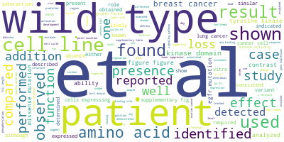

```python
from wordcloud import WordCloud
# Join the different processed titles together.
long_string = ','.join(list(train_text_df['Text_processed'].values))
# Create a WordCloud object
wordcloud = WordCloud(background_color="white", max_words=5000, contour_width=5, contour_color='steelblue')
# Generate a word cloud
wordcloud.generate(long_string)
# Visualize the word cloud
wordcloud.to_image()
```

```python
count_grp = train_full.groupby('Class')["Text_count"]
count_grp.describe()
```

| Class | count | mean | std | min | 25% | 50% | 75% | max |
| --- | --- | --- | --- | --- | --- | --- | --- | --- |
| 1 | 568.0 | 9441.841549 | 6511.773899 | 1.0 | 4969.75 | 7302.0 | 12866.25 | 52918.0 |
| 2 | 452.0 | 9304.159292 | 7621.158837 | 116.0 | 4185.00 | 6808.0 | 12219.50 | 61945.0 |
| 3 | 89.0 | 6749.213483 | 3712.931889 | 1737.0 | 4283.00 | 5571.0 | 7409.00 | 27290.0 |
| 4 | 686.0 | 8975.769679 | 7270.444322 | 53.0 | 4560.00 | 6351.0 | 11536.25 | 43812.0 |
| 5 | 242.0 | 7504.384298 | 3895.755024 | 183.0 | 5245.00 | 6426.0 | 9513.00 | 24130.0 |
| 6 | 275.0 | 7177.952727 | 3833.400979 | 1.0 | 4498.50 | 6587.0 | 7847.00 | 24519.0 |
| 7 | 953.0 | 11433.295908 | 10104.998688 | 1.0 | 4871.00 | 8254.0 | 14592.00 | 76733.0 |
| 8 | 19.0 | 10809.368421 | 5645.232888 | 2111.0 | 5586.00 | 11248.0 | 15529.00 | 20615.0 |
| 9 | 37.0 | 12795.675676 | 10208.050296 | 1147.0 | 4937.00 | 10910.0 | 15791.00 | 45078.0 |

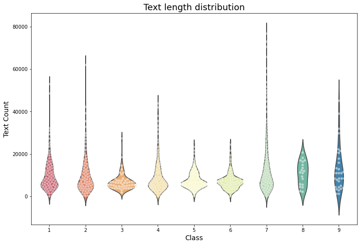

```python
plt.figure(figsize=(12,8))
gene_count_grp = train_full.groupby('Gene')["Text_count"].sum().reset_index()
sns.violinplot(x="Class", y="Text_count", data=train_full, inner=None,palette="Spectral")
sns.swarmplot(x="Class", y="Text_count", data=train_full, color="w", alpha=.5);
plt.ylabel('Text Count', fontsize=14)
plt.xlabel('Class', fontsize=14)
plt.title("Text length distribution", fontsize=18)
plt.show()
```

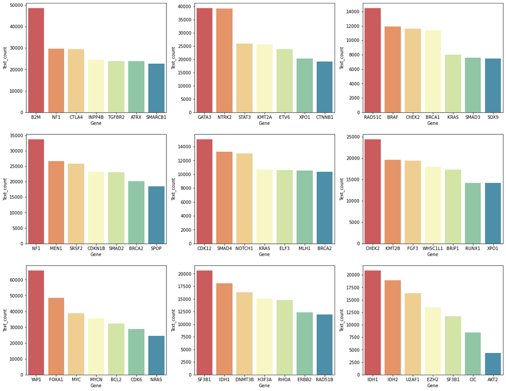

```python
fig, axs = plt.subplots(ncols=3, nrows=3, figsize=(20,16))

for i in range(3):
    for j in range(3):
        gene_count_grp = train_full[train_full["Class"]==((i*3+j)+1)].groupby('Gene')["Text_count"].mean().reset_index()
        sorted_gene_group = gene_count_grp.sort_values('Text_count', ascending=False)
        sorted_gene_group_top_7 = sorted_gene_group[:7]
        sns.barplot(x="Gene", y="Text_count", data=sorted_gene_group_top_7, ax=axs[i][j],palette="Spectral")
```

# Vector Representation

## CountVectorizer and TfidfVectorizer

Split each message into individual words/tokens (bag of words). Lemmatize the data (each word takes its base form, like “walking” or “walked” is replaced with “walk”). Convert data to vectors using scikit-learn module CountVectorizer. Run TFIDF to remove common words like “is,” “are,” “and.”

```python
train_full["Text_processed"]
```

```
0       cyclin-dependent kinases (cdks) regulate a var...
1       abstract background  non-small cell lung cance...
2       abstract background  non-small cell lung cance...
3       recent evidence has demonstrated that acquired...
4       oncogenic mutations in the monomeric casitas b...
                              ...
3316    introduction  myelodysplastic syndromes (mds) ...
3317    introduction  myelodysplastic syndromes (mds) ...
3318    the runt-related transcription factor 1 gene (...
3319    the runx1/aml1 gene is the most frequent targe...
3320    the most frequent mutations associated with le...
Name: Text_processed, Length: 3321, dtype: object
```

```python
test_full["Text_processed"]
```

```
0      the incidence of breast cancer is increasing i...
1      an unselected series of 310 colorectal carcino...
2      mycosis fungoides and sézary syndrome are prim...
3      regulated progression through the cell cycle r...
4      pilocytic astrocytoma (pa) is emerging as a tu...
                             ...
981    iκb kinase β (ikkβ) is involved in tumor devel...
982    he identification of subtype-specific transloc...
983    cardio-facio-cutaneous (cfc) syndrome (mim 115...
984    screening for tumor suppressor genes in breast...
985    histiocytic neoplasms are clonal hematopoietic...
Name: Text_processed, Length: 986, dtype: object
```

```python
val_full["Text_processed"]
```

```
0       2 this mutation resulted in a myeloproliferati...
1       abstract the large tumor suppressor 1 (lats1) ...
2       vascular endothelial growth factor receptor (v...
3       inflammatory myofibroblastic tumor (imt) is a ...
4       abstract retinoblastoma is a pediatric retinal...
                              ...
5663    the realization in the late 1970s that ras har...
5664    hemizygous deletions are common molecular abno...
5665    all most r267w of has with to smartpool invest...
5666    abstract blood samples from 125 unrelated fami...
5667    loss of dna mismatch repair (mmr) in humans ma...
Name: Text_processed, Length: 5668, dtype: object
```

```python
# from textblob import TextBlob

# def textblob_tokenizer(str_input):
#     blob = TextBlob(str_input.lower())
#     tokens = blob.words
#     words = [token.stem() for token in tokens]
#     return words

# count_vectorizer = CountVectorizer(tokenizer=textblob_tokenizer)

# count_data_train = count_vectorizer.fit_transform(train_full["Text_processed"])
# train_text = pd.DataFrame(count_data_train.toarray(), columns=count_vectorizer.get_feature_names())

# count_data_test = count_vectorizer.fit_transform(test_full["Text_processed"])
# test_text = pd.DataFrame(count_data_test.toarray(), columns=count_vectorizer.get_feature_names())
```

```python
# from sklearn.feature_extraction.text import TfidfVectorizer

# vec = TfidfVectorizer(tokenizer=textblob_tokenizer,
#                       stop_words='english',
#                       norm='l2',
#                       use_idf=False)
# matrix_train_text = vec.fit_transform(train_full["Text_processed"])
# train_text= pd.DataFrame(matrix_train_text.toarray(), columns=vec.get_feature_names())
# train_text
```

```python
# from sklearn.feature_extraction.text import TfidfVectorizer

# vec = TfidfVectorizer(tokenizer=textblob_tokenizer,
#                       stop_words='english',
#                       norm='l2',
#                       use_idf=False)
# matrix_test_text = vec.fit_transform(test_full["Text_processed"])
# test_text= pd.DataFrame(matrix_test_text.toarray(), columns=vec.get_feature_names())
# test_text
```

## Word2Vec

### CBOW and Skip Gram

```python
# Python program to generate word vectors using Word2Vec

# importing all necessary modules
from nltk.tokenize import sent_tokenize, word_tokenize
import warnings

warnings.filterwarnings(action = 'ignore')

import gensim
from gensim.models import Word2Vec

Word2Vec_dim = 200
train = train_full["Text_processed"].to_string()
test = test_full["Text_processed"].to_string()
val = val_full["Text_processed"].to_string()

# Replaces escape character with space
f = train.replace("\n", " ")

data = []

# iterate through each sentence in the file
for i in sent_tokenize(f):
    temp = []
    # tokenize the sentence into words
    for j in word_tokenize(i):
        temp.append(j.lower())

    data.append(temp)


# Replaces escape character with space
f2 = test.replace("\n", " ")

data2 = []

# iterate through each sentence in the file
for i in sent_tokenize(f2):
    temp2 = []
    # tokenize the sentence into words
    for j in word_tokenize(i):
        temp2.append(j.lower())

    data2.append(temp2)


# Replaces escape character with space
f3 = val.replace("\n", " ")

data3 = []

# iterate through each sentence in the file
for i in sent_tokenize(f3):
    temp3 = []
    # tokenize the sentence into words
    for j in word_tokenize(i):
        temp3.append(j.lower())

    data3.append(temp3)


# Create CBOW model
model1 = gensim.models.Word2Vec(data, min_count = 1,vector_size = Word2Vec_dim, window = 5)
model2 = gensim.models.Word2Vec(data2, min_count = 1,vector_size = Word2Vec_dim, window = 5)
model3 = gensim.models.Word2Vec(data3, min_count = 1,vector_size = Word2Vec_dim, window = 5)


#Create Skip Gram model
model4 = gensim.models.Word2Vec(data, min_count = 1, vector_size = Word2Vec_dim, window = 5, sg = 1)
model5 = gensim.models.Word2Vec(data2, min_count = 1, vector_size = Word2Vec_dim, window = 5, sg = 1)
# model6 = gensim.models.Word2Vec(data2, min_count = 1, vector_size = Word2Vec_dim, window = 5, sg = 1)
```

```python
# model1.save("word2vec.model1_CBOW")
# model2.save("word2vec.model2_CBOW")
# model3.save("word2vec.model3_CBOW")
# model4.save("word2vec.model4_SkipGram")
# model5.save("word2vec.model5_SkipGram")
# model6.save("word2vec.model6_SkipGram")
```

### Average feature vector

```python
def avg_feature_vector(sentence, model, num_features):
    words = sentence.replace('\n'," ").replace(',',' ').replace('.'," ").split()
    feature_vec = np.zeros((num_features,),dtype="float32")
    i=0
    for word in words:
        try:
            feature_vec = np.add(feature_vec, model[word])
        except KeyError as error:
            feature_vec
            i = i + 1
    if len(words) > 0:
        feature_vec = np.divide(feature_vec, len(words)- i)
    return feature_vec
```

```python
train_word2vec1 = np.zeros((len(train_full),Word2Vec_dim),dtype="float32")
test_word2vec1 = np.zeros((len(test_full),Word2Vec_dim),dtype="float32")
val_word2vec1 = np.zeros((len(val_full),Word2Vec_dim),dtype="float32")

for i in range(len(train_full)):
    train_word2vec1[i] = avg_feature_vector(train_full["Text_processed"][i],model1.wv, Word2Vec_dim)

for i in range(len(test_full)):
    test_word2vec1[i] = avg_feature_vector(test_full["Text_processed"][i],model1.wv, Word2Vec_dim)

for i in range(len(val_full)):
    val_word2vec1[i] = avg_feature_vector(val_full["Text_processed"][i],model1.wv, Word2Vec_dim)
```

```python
train_word2vec2 = np.zeros((len(train_full),Word2Vec_dim),dtype="float32")
test_word2vec2 = np.zeros((len(test_full),Word2Vec_dim),dtype="float32")
val_word2vec2 = np.zeros((len(val_full),Word2Vec_dim),dtype="float32")

for i in range(len(train_full)):
    train_word2vec2[i] = avg_feature_vector(train_full["Text_processed"][i],model4.wv, Word2Vec_dim)

for i in range(len(test_full)):
    test_word2vec2[i] = avg_feature_vector(test_full["Text_processed"][i],model4.wv, Word2Vec_dim)

for i in range(len(val_full)):
    val_word2vec2[i] = avg_feature_vector(val_full["Text_processed"][i],model4.wv, Word2Vec_dim)
```

```python
train_word2vec1 = pd.DataFrame(train_word2vec1)
train_word2vec1
```

|  | 0 | 1 | 2 | 3 | 4 | 5 | 6 | 7 | 8 | 9 | ... | 190 | 191 | 192 | 193 | 194 | 195 | 196 | 197 | 198 | 199 |
| --- | --- | --- | --- | --- | --- | --- | --- | --- | --- | --- | --- | --- | --- | --- | --- | --- | --- | --- | --- | --- | --- |
| 0 | 0.030558 | -0.015823 | 0.031584 | 0.155709 | 0.201423 | -0.203827 | 0.107792 | 0.333719 | -0.100138 | 0.067770 | ... | 0.156444 | 0.025101 | -0.085504 | -0.015761 | 0.130996 | 0.150581 | 0.103643 | -0.146327 | 0.045085 | -0.183692 |
| 1 | 0.029913 | -0.015750 | 0.031048 | 0.153403 | 0.198534 | -0.200847 | 0.106109 | 0.328901 | -0.098889 | 0.066972 | ... | 0.154458 | 0.024569 | -0.083954 | -0.015689 | 0.129120 | 0.148577 | 0.102213 | -0.144607 | 0.044623 | -0.181543 |
| 2 | 0.029913 | -0.015750 | 0.031048 | 0.153403 | 0.198534 | -0.200847 | 0.106109 | 0.328901 | -0.098889 | 0.066972 | ... | 0.154458 | 0.024569 | -0.083954 | -0.015689 | 0.129120 | 0.148577 | 0.102213 | -0.144607 | 0.044623 | -0.181543 |
| 3 | 0.026097 | -0.013590 | 0.027083 | 0.133261 | 0.172237 | -0.174206 | 0.092193 | 0.285599 | -0.085689 | 0.058011 | ... | 0.134285 | 0.021348 | -0.072891 | -0.013767 | 0.111947 | 0.129049 | 0.088804 | -0.125273 | 0.038687 | -0.157822 |
| 4 | 0.030946 | -0.016442 | 0.031900 | 0.159606 | 0.206035 | -0.208301 | 0.110192 | 0.341455 | -0.102866 | 0.069590 | ... | 0.160568 | 0.025679 | -0.086985 | -0.016342 | 0.134097 | 0.154578 | 0.106165 | -0.149948 | 0.046244 | -0.188934 |
| ... | ... | ... | ... | ... | ... | ... | ... | ... | ... | ... | ... | ... | ... | ... | ... | ... | ... | ... | ... | ... | ... |
| 3316 | 0.028244 | -0.014919 | 0.029750 | 0.146227 | 0.189128 | -0.190895 | 0.101158 | 0.313355 | -0.094322 | 0.063727 | ... | 0.147317 | 0.023716 | -0.080325 | -0.014886 | 0.123020 | 0.141623 | 0.097597 | -0.137638 | 0.042167 | -0.173109 |
| 3317 | 0.028506 | -0.015051 | 0.030034 | 0.147970 | 0.191326 | -0.193254 | 0.102404 | 0.317186 | -0.095345 | 0.064509 | ... | 0.149076 | 0.023971 | -0.081491 | -0.015036 | 0.124571 | 0.143278 | 0.098557 | -0.139363 | 0.042710 | -0.175217 |
| 3318 | 0.031277 | -0.016124 | 0.032222 | 0.158835 | 0.205211 | -0.207421 | 0.109845 | 0.339826 | -0.102035 | 0.069328 | ... | 0.159678 | 0.025296 | -0.087039 | -0.016584 | 0.133879 | 0.153550 | 0.105795 | -0.149330 | 0.045976 | -0.187533 |
| 3319 | 0.028738 | -0.015219 | 0.030077 | 0.146653 | 0.189820 | -0.191666 | 0.101135 | 0.314400 | -0.094518 | 0.064188 | ... | 0.147786 | 0.023508 | -0.080070 | -0.015042 | 0.123692 | 0.142048 | 0.097604 | -0.138128 | 0.042355 | -0.173554 |
| 3320 | 0.029808 | -0.015767 | 0.031072 | 0.152177 | 0.196966 | -0.198941 | 0.105114 | 0.326137 | -0.098102 | 0.066625 | ... | 0.153342 | 0.024383 | -0.083239 | -0.015608 | 0.128381 | 0.147478 | 0.101303 | -0.143341 | 0.043959 | -0.180079 |

3321 rows × 200 columns

```python
test_word2vec1 = pd.DataFrame(test_word2vec1)
test_word2vec1
```

|  | 0 | 1 | 2 | 3 | 4 | 5 | 6 | 7 | 8 | 9 | ... | 190 | 191 | 192 | 193 | 194 | 195 | 196 | 197 | 198 | 199 |
| --- | --- | --- | --- | --- | --- | --- | --- | --- | --- | --- | --- | --- | --- | --- | --- | --- | --- | --- | --- | --- | --- |
| 0 | 0.027873 | -0.014384 | 0.028767 | 0.142185 | 0.184457 | -0.186445 | 0.098165 | 0.304925 | -0.091732 | 0.062141 | ... | 0.143329 | 0.022899 | -0.077952 | -0.014823 | 0.119887 | 0.138087 | 0.094909 | -0.134078 | 0.041444 | -0.168758 |
| 1 | 0.030813 | -0.016298 | 0.031926 | 0.157806 | 0.203931 | -0.205898 | 0.108995 | 0.337965 | -0.101602 | 0.068727 | ... | 0.158718 | 0.025517 | -0.086128 | -0.016030 | 0.132859 | 0.152582 | 0.105149 | -0.148706 | 0.045566 | -0.186436 |
| 2 | 0.029845 | -0.015578 | 0.030984 | 0.152979 | 0.197728 | -0.199727 | 0.105538 | 0.327341 | -0.098491 | 0.066707 | ... | 0.153812 | 0.024514 | -0.083935 | -0.015649 | 0.128687 | 0.147902 | 0.101800 | -0.143773 | 0.044303 | -0.180875 |
| 3 | 0.029619 | -0.015685 | 0.030910 | 0.151989 | 0.195936 | -0.198489 | 0.104928 | 0.325224 | -0.097577 | 0.066057 | ... | 0.152867 | 0.024328 | -0.082845 | -0.015404 | 0.127825 | 0.146821 | 0.101232 | -0.142636 | 0.044029 | -0.179549 |
| 4 | 0.031120 | -0.016207 | 0.032119 | 0.158538 | 0.204554 | -0.207080 | 0.109454 | 0.339084 | -0.101951 | 0.069037 | ... | 0.159108 | 0.025189 | -0.086710 | -0.016276 | 0.133293 | 0.153324 | 0.105390 | -0.148998 | 0.045898 | -0.187250 |
| ... | ... | ... | ... | ... | ... | ... | ... | ... | ... | ... | ... | ... | ... | ... | ... | ... | ... | ... | ... | ... | ... |
| 981 | 0.028904 | -0.015295 | 0.029971 | 0.148099 | 0.191162 | -0.193542 | 0.102271 | 0.317110 | -0.095424 | 0.064629 | ... | 0.149035 | 0.023667 | -0.081015 | -0.015167 | 0.124627 | 0.143352 | 0.098538 | -0.139337 | 0.042776 | -0.175249 |
| 982 | 0.029217 | -0.015222 | 0.029913 | 0.149103 | 0.192945 | -0.194871 | 0.103124 | 0.319532 | -0.096135 | 0.064923 | ... | 0.149767 | 0.023886 | -0.081893 | -0.015136 | 0.125603 | 0.144261 | 0.099146 | -0.140341 | 0.043082 | -0.176394 |
| 983 | 0.027676 | -0.014697 | 0.028575 | 0.140886 | 0.182257 | -0.184339 | 0.097566 | 0.302416 | -0.090616 | 0.061470 | ... | 0.142173 | 0.022505 | -0.077101 | -0.014594 | 0.118676 | 0.136407 | 0.093957 | -0.132573 | 0.040538 | -0.166691 |
| 984 | 0.030117 | -0.015594 | 0.031038 | 0.154602 | 0.199624 | -0.201670 | 0.106967 | 0.330470 | -0.099434 | 0.067442 | ... | 0.155156 | 0.024722 | -0.084709 | -0.015792 | 0.130030 | 0.149536 | 0.102887 | -0.145285 | 0.044656 | -0.182703 |
| 985 | 0.027877 | -0.014902 | 0.029075 | 0.142706 | 0.184475 | -0.186375 | 0.098657 | 0.305922 | -0.092050 | 0.062082 | ... | 0.143814 | 0.022669 | -0.078298 | -0.014567 | 0.120253 | 0.138015 | 0.094961 | -0.134338 | 0.041408 | -0.168760 |

986 rows × 200 columns

```python
val_word2vec1 = pd.DataFrame(val_word2vec1)
val_word2vec1
```

|  | 0 | 1 | 2 | 3 | 4 | 5 | 6 | 7 | 8 | 9 | ... | 190 | 191 | 192 | 193 | 194 | 195 | 196 | 197 | 198 | 199 |
| --- | --- | --- | --- | --- | --- | --- | --- | --- | --- | --- | --- | --- | --- | --- | --- | --- | --- | --- | --- | --- | --- |
| 0 | 0.027797 | -0.014555 | 0.028963 | 0.143663 | 0.185587 | -0.187408 | 0.099082 | 0.307519 | -0.092349 | 0.062725 | ... | 0.144695 | 0.023037 | -0.078530 | -0.014493 | 0.120727 | 0.139021 | 0.095292 | -0.134969 | 0.041572 | -0.169719 |
| 1 | 0.027644 | -0.014532 | 0.028557 | 0.140854 | 0.182010 | -0.184278 | 0.097633 | 0.301636 | -0.090770 | 0.061338 | ... | 0.141625 | 0.022520 | -0.077508 | -0.014348 | 0.118469 | 0.136208 | 0.093731 | -0.132655 | 0.040753 | -0.166529 |
| 2 | 0.029656 | -0.015644 | 0.030797 | 0.152391 | 0.196808 | -0.198769 | 0.105307 | 0.325763 | -0.098027 | 0.066379 | ... | 0.152999 | 0.024255 | -0.083480 | -0.015454 | 0.128172 | 0.147297 | 0.101311 | -0.143275 | 0.043992 | -0.180071 |
| 3 | 0.030690 | -0.015660 | 0.031792 | 0.156027 | 0.201352 | -0.203799 | 0.108014 | 0.333720 | -0.100145 | 0.067936 | ... | 0.156742 | 0.025236 | -0.085516 | -0.016055 | 0.131335 | 0.150758 | 0.103615 | -0.146544 | 0.045166 | -0.184385 |
| 4 | 0.027177 | -0.014450 | 0.028327 | 0.140123 | 0.180791 | -0.182652 | 0.096789 | 0.299520 | -0.090191 | 0.060878 | ... | 0.140782 | 0.022395 | -0.076761 | -0.014055 | 0.117615 | 0.135329 | 0.092996 | -0.131563 | 0.040426 | -0.165506 |
| ... | ... | ... | ... | ... | ... | ... | ... | ... | ... | ... | ... | ... | ... | ... | ... | ... | ... | ... | ... | ... | ... |
| 5663 | 0.030937 | -0.016241 | 0.032128 | 0.158727 | 0.205100 | -0.207512 | 0.109821 | 0.340032 | -0.102355 | 0.069503 | ... | 0.159753 | 0.025382 | -0.086977 | -0.016105 | 0.133586 | 0.153548 | 0.105723 | -0.149450 | 0.045959 | -0.188001 |
| 5664 | 0.032314 | -0.016879 | 0.033504 | 0.164366 | 0.212193 | -0.214635 | 0.113764 | 0.351983 | -0.105731 | 0.071733 | ... | 0.165321 | 0.026253 | -0.090051 | -0.016859 | 0.138502 | 0.158989 | 0.109486 | -0.154585 | 0.047317 | -0.194479 |
| 5665 | 0.029237 | -0.015366 | 0.029857 | 0.150109 | 0.193745 | -0.195603 | 0.103329 | 0.320630 | -0.096723 | 0.065662 | ... | 0.150870 | 0.023933 | -0.081918 | -0.015466 | 0.126362 | 0.145191 | 0.099660 | -0.141066 | 0.043359 | -0.177418 |
| 5666 | 0.025499 | -0.013622 | 0.026726 | 0.131627 | 0.170049 | -0.172205 | 0.091129 | 0.281851 | -0.084733 | 0.057535 | ... | 0.132445 | 0.021041 | -0.072054 | -0.013460 | 0.110680 | 0.127246 | 0.087623 | -0.123875 | 0.038130 | -0.155645 |
| 5667 | 0.028911 | -0.015159 | 0.029996 | 0.147760 | 0.190903 | -0.192909 | 0.101715 | 0.316099 | -0.095108 | 0.064478 | ... | 0.148538 | 0.023505 | -0.080925 | -0.015164 | 0.124291 | 0.142854 | 0.098437 | -0.138883 | 0.042584 | -0.174903 |

5668 rows × 200 columns

```python
train_word2vec2 = pd.DataFrame(train_word2vec2)
train_word2vec2
```

|  | 0 | 1 | 2 | 3 | 4 | 5 | 6 | 7 | 8 | 9 | ... | 190 | 191 | 192 | 193 | 194 | 195 | 196 | 197 | 198 | 199 |
| --- | --- | --- | --- | --- | --- | --- | --- | --- | --- | --- | --- | --- | --- | --- | --- | --- | --- | --- | --- | --- | --- |
| 0 | -0.030383 | 0.071011 | 0.031994 | 0.148302 | 0.238358 | -0.201040 | 0.029742 | 0.219743 | -0.030415 | 0.081891 | ... | 0.098515 | 0.026475 | -0.148029 | -0.025435 | 0.109089 | 0.082679 | 0.016505 | -0.111585 | 0.027443 | -0.121706 |
| 1 | -0.030999 | 0.071811 | 0.032271 | 0.151052 | 0.241898 | -0.204054 | 0.029108 | 0.223518 | -0.031446 | 0.083994 | ... | 0.101145 | 0.026174 | -0.149361 | -0.025096 | 0.109990 | 0.084445 | 0.017632 | -0.113752 | 0.027283 | -0.125380 |
| 2 | -0.030999 | 0.071811 | 0.032271 | 0.151052 | 0.241898 | -0.204054 | 0.029108 | 0.223518 | -0.031446 | 0.083994 | ... | 0.101145 | 0.026174 | -0.149361 | -0.025096 | 0.109990 | 0.084445 | 0.017632 | -0.113752 | 0.027283 | -0.125380 |
| 3 | -0.028756 | 0.065961 | 0.029191 | 0.137049 | 0.218716 | -0.183962 | 0.026216 | 0.202378 | -0.029009 | 0.075954 | ... | 0.092375 | 0.022654 | -0.134818 | -0.021963 | 0.099162 | 0.076736 | 0.015799 | -0.102761 | 0.024996 | -0.114678 |
| 4 | -0.031675 | 0.072344 | 0.031047 | 0.151858 | 0.241169 | -0.202997 | 0.029066 | 0.223719 | -0.032095 | 0.084197 | ... | 0.102371 | 0.025877 | -0.149269 | -0.024113 | 0.108965 | 0.085105 | 0.017677 | -0.113416 | 0.027036 | -0.127469 |
| ... | ... | ... | ... | ... | ... | ... | ... | ... | ... | ... | ... | ... | ... | ... | ... | ... | ... | ... | ... | ... | ... |
| 3316 | -0.029181 | 0.066342 | 0.029586 | 0.138819 | 0.222119 | -0.186451 | 0.026261 | 0.205545 | -0.029472 | 0.077217 | ... | 0.093584 | 0.024058 | -0.137519 | -0.022430 | 0.101082 | 0.078283 | 0.016390 | -0.104326 | 0.024529 | -0.115970 |
| 3317 | -0.028902 | 0.065772 | 0.029122 | 0.137284 | 0.220144 | -0.184807 | 0.025878 | 0.203792 | -0.029035 | 0.076594 | ... | 0.092870 | 0.024092 | -0.136774 | -0.022351 | 0.100410 | 0.077601 | 0.015963 | -0.103410 | 0.024204 | -0.114841 |
| 3318 | -0.028973 | 0.069381 | 0.031818 | 0.145812 | 0.234524 | -0.197794 | 0.029426 | 0.216080 | -0.029317 | 0.080629 | ... | 0.096773 | 0.026897 | -0.146285 | -0.026416 | 0.108304 | 0.081855 | 0.016247 | -0.109836 | 0.026760 | -0.119283 |
| 3319 | -0.029143 | 0.067740 | 0.030247 | 0.143024 | 0.227894 | -0.191572 | 0.026494 | 0.211270 | -0.029985 | 0.079677 | ... | 0.096606 | 0.024325 | -0.140108 | -0.022365 | 0.103526 | 0.080175 | 0.016771 | -0.107204 | 0.024775 | -0.119598 |
| 3320 | -0.029635 | 0.068570 | 0.030715 | 0.144819 | 0.230963 | -0.194281 | 0.027381 | 0.213977 | -0.030236 | 0.080577 | ... | 0.097454 | 0.024884 | -0.142515 | -0.023170 | 0.105094 | 0.081352 | 0.016845 | -0.108638 | 0.025342 | -0.120796 |

3321 rows × 200 columns

```python
test_word2vec2 = pd.DataFrame(test_word2vec2)
test_word2vec2
```

|  | 0 | 1 | 2 | 3 | 4 | 5 | 6 | 7 | 8 | 9 | ... | 190 | 191 | 192 | 193 | 194 | 195 | 196 | 197 | 198 | 199 |
| --- | --- | --- | --- | --- | --- | --- | --- | --- | --- | --- | --- | --- | --- | --- | --- | --- | --- | --- | --- | --- | --- |
| 0 | -0.028886 | 0.068720 | 0.030642 | 0.142843 | 0.230460 | -0.194146 | 0.027563 | 0.211902 | -0.029839 | 0.079811 | ... | 0.096180 | 0.025408 | -0.142412 | -0.024593 | 0.105587 | 0.080331 | 0.016476 | -0.107847 | 0.026164 | -0.118517 |
| 1 | -0.029921 | 0.069765 | 0.031721 | 0.148390 | 0.237293 | -0.199699 | 0.028592 | 0.219514 | -0.030604 | 0.082132 | ... | 0.098801 | 0.026699 | -0.146759 | -0.024999 | 0.108556 | 0.083024 | 0.017284 | -0.111875 | 0.026239 | -0.122425 |
| 2 | -0.030514 | 0.070207 | 0.031069 | 0.147003 | 0.234675 | -0.197142 | 0.027883 | 0.216730 | -0.030809 | 0.081628 | ... | 0.098449 | 0.025168 | -0.145176 | -0.023748 | 0.106752 | 0.082223 | 0.016994 | -0.110244 | 0.026359 | -0.122514 |
| 3 | -0.030665 | 0.069960 | 0.031107 | 0.147896 | 0.234472 | -0.198135 | 0.028366 | 0.217458 | -0.030473 | 0.081373 | ... | 0.099138 | 0.025140 | -0.144849 | -0.023249 | 0.106489 | 0.082452 | 0.017138 | -0.110380 | 0.026389 | -0.123228 |
| 4 | -0.030558 | 0.071789 | 0.032253 | 0.151257 | 0.240687 | -0.203111 | 0.029944 | 0.222672 | -0.030748 | 0.083123 | ... | 0.099953 | 0.026540 | -0.149618 | -0.025547 | 0.109831 | 0.084020 | 0.016808 | -0.113334 | 0.027515 | -0.124642 |
| ... | ... | ... | ... | ... | ... | ... | ... | ... | ... | ... | ... | ... | ... | ... | ... | ... | ... | ... | ... | ... | ... |
| 981 | -0.031015 | 0.070329 | 0.031773 | 0.148485 | 0.235880 | -0.199086 | 0.028224 | 0.218482 | -0.031176 | 0.082104 | ... | 0.099105 | 0.024908 | -0.145673 | -0.023926 | 0.107290 | 0.083055 | 0.017168 | -0.111379 | 0.026525 | -0.123733 |
| 982 | -0.028608 | 0.066946 | 0.029733 | 0.140606 | 0.225485 | -0.189971 | 0.027338 | 0.208333 | -0.029212 | 0.077951 | ... | 0.093661 | 0.024984 | -0.140210 | -0.023677 | 0.103094 | 0.078901 | 0.015915 | -0.105798 | 0.025259 | -0.116371 |
| 983 | -0.029025 | 0.067039 | 0.030066 | 0.141192 | 0.225553 | -0.189674 | 0.027022 | 0.209226 | -0.029340 | 0.078448 | ... | 0.095029 | 0.023895 | -0.138922 | -0.023003 | 0.102759 | 0.079154 | 0.016416 | -0.105977 | 0.024915 | -0.117662 |
| 984 | -0.030124 | 0.070243 | 0.030870 | 0.147860 | 0.235955 | -0.199029 | 0.028856 | 0.217568 | -0.030631 | 0.082246 | ... | 0.098546 | 0.026052 | -0.146406 | -0.024037 | 0.107524 | 0.082980 | 0.017304 | -0.110862 | 0.026355 | -0.122551 |
| 985 | -0.029058 | 0.066840 | 0.030960 | 0.141407 | 0.226625 | -0.190734 | 0.027393 | 0.209227 | -0.029664 | 0.078218 | ... | 0.094353 | 0.024405 | -0.140088 | -0.023930 | 0.104078 | 0.078984 | 0.016154 | -0.106464 | 0.025730 | -0.116700 |

986 rows × 200 columns

```python
val_word2vec2 = pd.DataFrame(val_word2vec2)
val_word2vec2
```

|  | 0 | 1 | 2 | 3 | 4 | 5 | 6 | 7 | 8 | 9 | ... | 190 | 191 | 192 | 193 | 194 | 195 | 196 | 197 | 198 | 199 |
| --- | --- | --- | --- | --- | --- | --- | --- | --- | --- | --- | --- | --- | --- | --- | --- | --- | --- | --- | --- | --- | --- |
| 0 | -0.030323 | 0.069442 | 0.029834 | 0.144520 | 0.229415 | -0.192390 | 0.027442 | 0.212716 | -0.030145 | 0.080294 | ... | 0.097296 | 0.024042 | -0.141600 | -0.022052 | 0.103741 | 0.080955 | 0.016256 | -0.107904 | 0.025919 | -0.121039 |
| 1 | -0.028736 | 0.067667 | 0.031730 | 0.143628 | 0.231688 | -0.196263 | 0.028708 | 0.212869 | -0.030031 | 0.079874 | ... | 0.095649 | 0.026023 | -0.143829 | -0.025450 | 0.106957 | 0.080554 | 0.016585 | -0.108814 | 0.026101 | -0.117444 |
| 2 | -0.031152 | 0.071084 | 0.031509 | 0.148716 | 0.236898 | -0.199092 | 0.029323 | 0.218341 | -0.030891 | 0.082051 | ... | 0.098810 | 0.025039 | -0.146720 | -0.024113 | 0.107740 | 0.082516 | 0.016535 | -0.111620 | 0.027184 | -0.123372 |
| 3 | -0.029913 | 0.071006 | 0.032048 | 0.148188 | 0.236898 | -0.199863 | 0.030392 | 0.218469 | -0.029629 | 0.081392 | ... | 0.097924 | 0.026871 | -0.147644 | -0.025769 | 0.108589 | 0.082347 | 0.015730 | -0.111215 | 0.027615 | -0.121774 |
| 4 | -0.029810 | 0.068192 | 0.030574 | 0.144395 | 0.230120 | -0.194106 | 0.027976 | 0.212298 | -0.030445 | 0.079937 | ... | 0.096627 | 0.024669 | -0.142280 | -0.023020 | 0.104841 | 0.080679 | 0.016606 | -0.108273 | 0.025695 | -0.119635 |
| ... | ... | ... | ... | ... | ... | ... | ... | ... | ... | ... | ... | ... | ... | ... | ... | ... | ... | ... | ... | ... | ... |
| 5663 | -0.031625 | 0.070880 | 0.031441 | 0.148979 | 0.236217 | -0.199277 | 0.029063 | 0.218796 | -0.030963 | 0.082228 | ... | 0.098982 | 0.024948 | -0.146534 | -0.023656 | 0.106745 | 0.082790 | 0.016799 | -0.111648 | 0.027002 | -0.124433 |
| 5664 | -0.030550 | 0.070990 | 0.032514 | 0.150582 | 0.240119 | -0.202675 | 0.029610 | 0.222260 | -0.030631 | 0.083196 | ... | 0.099966 | 0.026589 | -0.149041 | -0.025319 | 0.109925 | 0.084298 | 0.017181 | -0.113202 | 0.026826 | -0.124705 |
| 5665 | -0.029560 | 0.068490 | 0.029801 | 0.144115 | 0.229633 | -0.193175 | 0.027431 | 0.211962 | -0.030207 | 0.080213 | ... | 0.096158 | 0.025069 | -0.142243 | -0.023647 | 0.105235 | 0.081054 | 0.016254 | -0.108272 | 0.025989 | -0.119581 |
| 5666 | -0.028435 | 0.065087 | 0.029278 | 0.136220 | 0.218326 | -0.184303 | 0.026412 | 0.201343 | -0.029019 | 0.076082 | ... | 0.091571 | 0.023093 | -0.134932 | -0.022416 | 0.099772 | 0.076225 | 0.015733 | -0.102673 | 0.024776 | -0.113101 |
| 5667 | -0.029826 | 0.068886 | 0.030434 | 0.144172 | 0.229991 | -0.193365 | 0.026884 | 0.212715 | -0.030278 | 0.080260 | ... | 0.097049 | 0.024273 | -0.142211 | -0.022850 | 0.104517 | 0.080768 | 0.016934 | -0.108076 | 0.025450 | -0.120773 |

5668 rows × 200 columns

# Modeling

## LightGBM

LightGBM（Light Gradient Boosting Machine）是一个实现GBDT算法的框架，支持高效率的并行训练，并且具有更快的训练速度、更低的内存消耗、更好的准确率、支持分布式可以快速处理海量数据等优点。GBDT (Gradient Boosting Decision Tree) 是机器学习中一个长盛不衰的模型，其主要思想是利用弱分类器（决策树）迭代训练以得到最优模型，该模型具有训练效果好、不易过拟合等优点。 https://zhuanlan.zhihu.com/p/99069186

```python
lbl = preprocessing.LabelEncoder()

# 加载数据
data1 = train_word2vec1
data2 = train_word2vec2
target = lbl.fit_transform(train_full["Class"].astype(str))#将提示的包含错误数据类型这一列进行转换

# 划分训练集和测试集
X_train1, X_test1, y_train1, y_test1 = train_test_split(data1,target,test_size=0.3, random_state = 42)
X_train2, X_test2, y_train2, y_test2 = train_test_split(data2,target,test_size=0.3, random_state = 42)
print("Model1: Train data length:", len(X_train1))
print("Model1: Test data length:", len(X_test1))
print("Model2: Train data length:", len(X_train2))
print("Model2: Test data length:", len(X_test2))

# 转换为Dataset数据格式
lgb_train1 = lgb.Dataset(X_train1, y_train1)
lgb_eval1 = lgb.Dataset(X_test1, y_test1, reference=lgb_train1)
lgb_train2 = lgb.Dataset(X_train2, y_train2)
lgb_eval2 = lgb.Dataset(X_test2, y_test2, reference=lgb_train2)


params = {
    'task':'train',
    'boosting_type':'gbdt',
    'objective': 'multiclass',
    'num_class': 9,
    'metric': 'multi_error',
    'num_leaves': 500,
    'min_data_in_leaf': 100,
    'learning_rate': 0.1,
    'feature_fraction': 0.9,
    'bagging_fraction': 0.8,
    'bagging_freq': 5,
    'lambda_l1': 0.4,
    'lambda_l2': 0.5,
    'min_gain_to_split': 0.2,
    'verbose': -1,
}

# 模型训练
gbm1 = lgb.train(params, lgb_train1, num_boost_round=1000, valid_sets=lgb_eval1, verbose_eval = 50, early_stopping_rounds=300)
gbm2 = lgb.train(params, lgb_train2, num_boost_round=1000, valid_sets=lgb_eval2, verbose_eval = 50, early_stopping_rounds=300)


# 模型保存
gbm1.save_model('model1_CBOW.txt')
gbm2.save_model('model2_Skip_gram.txt')

# 模型加载
gbm1 = lgb.Booster(model_file='model1_CBOW.txt')
gbm2 = lgb.Booster(model_file='model2_Skip_gram.txt')

# 模型预测
y_prob1 = gbm1.predict(X_test1, num_iteration=gbm1.best_iteration)
y_pred_lightGBM1 = [list(x).index(max(x)) for x in y_prob1]


y_prob2 = gbm2.predict(X_test2, num_iteration=gbm2.best_iteration)
y_pred_lightGBM2 = [list(x).index(max(x)) for x in y_prob2]
```

```
Model1: Train data length: 2324
Model1: Test data length: 997
Model2: Train data length: 2324
Model2: Test data length: 997
Training until validation scores don't improve for 300 rounds
[50]	valid_0's multi_error: 0.437312
[100]	valid_0's multi_error: 0.418255
[150]	valid_0's multi_error: 0.417252
[200]	valid_0's multi_error: 0.418255
[250]	valid_0's multi_error: 0.412237
[300]	valid_0's multi_error: 0.417252
[350]	valid_0's multi_error: 0.415246
[400]	valid_0's multi_error: 0.416249
[450]	valid_0's multi_error: 0.406219
[500]	valid_0's multi_error: 0.406219
[550]	valid_0's multi_error: 0.402207
[600]	valid_0's multi_error: 0.408225
[650]	valid_0's multi_error: 0.402207
[700]	valid_0's multi_error: 0.410231
[750]	valid_0's multi_error: 0.408225
Early stopping, best iteration is:
[491]	valid_0's multi_error: 0.398195
Training until validation scores don't improve for 300 rounds
[50]	valid_0's multi_error: 0.40321
[100]	valid_0's multi_error: 0.408225
[150]	valid_0's multi_error: 0.409228
[200]	valid_0's multi_error: 0.398195
[250]	valid_0's multi_error: 0.402207
[300]	valid_0's multi_error: 0.405216
[350]	valid_0's multi_error: 0.405216
[400]	valid_0's multi_error: 0.405216
[450]	valid_0's multi_error: 0.404213
[500]	valid_0's multi_error: 0.414243
Early stopping, best iteration is:
[214]	valid_0's multi_error: 0.390171
```

```python
pred_lightgbm_cbow = gbm1.predict(test_word2vec1)
#pred_lightgbm_cbow = [list(x).index(max(x)) for x in pred_lightgbm_cbow]
#pred_lightgbm_cbow = pd.get_dummies(np.array(pred_lightgbm_cbow) + 1)
pred_lightgbm_cbow
```

```
array([[8.18594799e-01, 5.42538862e-03, 2.75871321e-03, ...,
        3.16385475e-03, 9.82712589e-05, 4.44391850e-05],
       [1.17365949e-01, 2.14578156e-01, 3.07850134e-04, ...,
        3.93607607e-01, 4.41260639e-04, 2.21272603e-03],
       [5.56807552e-02, 1.55908358e-01, 3.39474585e-04, ...,
        2.14087761e-01, 1.60671966e-03, 5.37428816e-04],
       ...,
       [2.22669974e-01, 4.03995260e-01, 1.07315209e-02, ...,
        1.88165624e-01, 2.60804118e-04, 1.91468348e-02],
       [1.84898293e-01, 3.38838708e-02, 2.27071358e-03, ...,
        2.94994233e-01, 1.42595836e-03, 9.30178109e-04],
       [1.91044256e-01, 2.05407440e-02, 2.23776327e-03, ...,
        7.51961259e-01, 5.21556327e-03, 2.56048268e-03]])
```

```python
# pred_lightgbm_skg = gbm2.predict(test_word2vec2)
# pred_lightgbm_skg = [list(x).index(max(x)) for x in pred_lightgbm_skg]
# pred_lightgbm_skg = pd.get_dummies(np.array(pred_lightgbm_skg) + 1)
# pred_lightgbm_skg
```

## RNN

```python
# 文本标签分类数量
NUM_CLASS=9
# 输入维度
VOCABULARY_SIZE = 10000
SEQUENCE_LENGTH= 1000
# # 序列对齐文本数据
# Tokenizer是一个用于向量化文本，或将文本转换为序列
tokenizer = Tokenizer(filters='!"#$%&()*+,-./:;<=>?@[\\]^_`{|}~\t\n',lower=True,split=" ")
tokenizer.fit_on_texts(train_full["Text_processed"])
vocab = tokenizer.word_index
```

```python
# Training
training = train_full.sample(frac=1) # shuffle data first
training_input = tokenizer.texts_to_sequences(training['Text_processed'].astype(str))
training_input_r = [list(reversed(x)) for x in training_input]
training_input_begin = pad_sequences(training_input, maxlen=SEQUENCE_LENGTH)
training_input_end = pad_sequences(training_input_r, maxlen=SEQUENCE_LENGTH)
training_output = pd.get_dummies(training['Class']).values

# Testing
testing_input = tokenizer.texts_to_sequences(test_full['Text_processed'].astype(str))
testing_input_r = [list(reversed(x)) for x in testing_input]
testing_input_begin = pad_sequences(testing_input, maxlen=SEQUENCE_LENGTH)
testing_input_end = pad_sequences(testing_input_r, maxlen=SEQUENCE_LENGTH)

# Validation
val_input = tokenizer.texts_to_sequences(val_full['Text_processed'].astype(str))
val_input_r = [list(reversed(x)) for x in val_input]
val_input_begin = pad_sequences(val_input, maxlen=SEQUENCE_LENGTH)
val_input_end = pad_sequences(val_input_r, maxlen=SEQUENCE_LENGTH)
val_output = pd.get_dummies(val_full['Class']).values
```

```python
print("Training set shape:",training_input_begin.shape, training_input_end.shape, training_output.shape)
print("Testing set shape:",testing_input_begin.shape, testing_input_end.shape)
print("Validation set shape:",val_input_begin.shape, val_input_end.shape, val_output.shape)
```

```
Training set shape: (3321, 1000) (3321, 1000) (3321, 9)
Testing set shape: (986, 1000) (986, 1000)
Validation set shape: (5668, 1000) (5668, 1000) (5668, 9)
```

```python
# Add gene and variation to predictor
gene_label = LabelEncoder()
ALL_Genes = np.concatenate([train_full['Gene'], val_full['Gene'], test_full['Gene']])
ALL_Variations = np.concatenate([train_full['Variation'], val_full['Variation'], test_full['Variation']])
ALL_Variations = np.asarray([v[0]+v[-1] for v in ALL_Variations])
print ("The number of unique genes: ", len(np.unique(ALL_Genes)))
print ("The number of unique variations:", len(np.unique(ALL_Variations)))
```

```
The number of unique genes:  1522
The number of unique variations: 347
```

```python
len_train = len(training_input)
len_validation = len(val_input)
len_test = len(testing_input)
print("The length of training input:", len_train)
print("The length of testing input:", len_test)
print("The length of validation input:", len_validation)
```

```
The length of training input: 3321
The length of testing input: 986
The length of validation input: 5668
```

```python
gene_encoded = pd.get_dummies(ALL_Genes).values
variation_encoded = pd.get_dummies(ALL_Variations).values
training_input_gene = gene_encoded[:len_train]
training_input_variation = variation_encoded[:len_train]
testing_input_gene = gene_encoded[-len_test:]
testing_input_variation = variation_encoded[-len_test:]
val_input_gene = gene_encoded[len_train:-len_test]
val_input_variation = variation_encoded[len_train:-len_test]
print (len(training_input_gene))
print (len(testing_input_gene))
print (len(val_input_gene))
```

```
3321
986
5668
```

```python
def dot_product(x, kernel):
    if K.backend() == 'tensorflow':
        return K.squeeze(K.dot(x, K.expand_dims(kernel)), axis=-1)
    else:
        return K.dot(x, kernel)
```

```python
class AttentionWithContext(Layer):
    def __init__(self,
                 W_regularizer=None, u_regularizer=None, b_regularizer=None,
                 W_constraint=None, u_constraint=None, b_constraint=None,
                 bias=True, **kwargs):

        self.supports_masking = True
        self.init = initializers.get('glorot_uniform')

        self.W_regularizer = regularizers.get(W_regularizer)
        self.u_regularizer = regularizers.get(u_regularizer)
        self.b_regularizer = regularizers.get(b_regularizer)

        self.W_constraint = constraints.get(W_constraint)
        self.u_constraint = constraints.get(u_constraint)
        self.b_constraint = constraints.get(b_constraint)

        self.bias = bias
        super(AttentionWithContext, self).__init__(**kwargs)

    def build(self, input_shape):
        assert len(input_shape) == 3

        self.W = self.add_weight(shape = (input_shape[-1], input_shape[-1],),
                                 initializer=self.init,
                                 name='{}_W'.format(self.name),
                                 regularizer=self.W_regularizer,
                                 constraint=self.W_constraint)
        if self.bias:
            self.b = self.add_weight(shape = (input_shape[-1],),
                                     initializer='zero',
                                     name='{}_b'.format(self.name),
                                     regularizer=self.b_regularizer,
                                     constraint=self.b_constraint)

        self.u = self.add_weight(shape = (input_shape[-1],),
                                 initializer=self.init,
                                 name='{}_u'.format(self.name),
                                 regularizer=self.u_regularizer,
                                 constraint=self.u_constraint)

        super(AttentionWithContext, self).build(input_shape)

    def compute_mask(self, input, input_mask=None):
        # do not pass the mask to the next layers
        return None

    def call(self, x, mask=None):
        uit = dot_product(x, self.W)

        if self.bias:
            uit += self.b

        uit = K.tanh(uit)
        ait = dot_product(uit, self.u)

        a = K.exp(ait)

        # apply mask after the exp. will be re-normalized next
        if mask is not None:
            # Cast the mask to floatX to avoid float64 upcasting in theano
            a *= K.cast(mask, K.floatx())

        # in some cases especially in the early stages of training the sum may be almost zero
        # and this results in NaN's. A workaround is to add a very small positive number ε to the sum.
        # a /= K.cast(K.sum(a, axis=1, keepdims=True), K.floatx())
        a /= K.cast(K.sum(a, axis=1, keepdims=True) + K.epsilon(), K.floatx())

        a = K.expand_dims(a)
        weighted_input = x * a
        return K.sum(weighted_input, axis=1)

    def compute_output_shape(self, input_shape):
        return input_shape[0], input_shape[-1]
```

```python
#The number of unique genes:  1522
#The number of unique variations: 347
```

```python
# Build out our simple LSTM
Embedding_dim = 200
lstm_out = 64

# Model saving callback
ckpt_callback = ModelCheckpoint('keras_model', monitor='val_loss', verbose=1, save_best_only=True, mode='auto')

input_sequence_begin = Input(shape=(training_input_begin.shape[1],))
input_sequence_end = Input(shape=(training_input_end.shape[1],))
input_gene = Input(shape=(training_input_gene.shape[1],))
input_variant = Input(shape=(training_input_variation.shape[1],))

merged = concatenate([input_gene, input_variant])
dense = Dense(32, activation='sigmoid')(merged)

embeds_begin = Embedding(VOCABULARY_SIZE, Embedding_dim, input_length = SEQUENCE_LENGTH)(input_sequence_begin)
embeds_out_begin = Bidirectional(GRU(lstm_out, recurrent_dropout=0.2, dropout=0.2, return_sequences=True))(embeds_begin)
attention_begin = AttentionWithContext()(embeds_out_begin)

embeds_end = Embedding(VOCABULARY_SIZE, Embedding_dim, input_length = SEQUENCE_LENGTH)(input_sequence_end)
embeds_out_end = Bidirectional(GRU(lstm_out, recurrent_dropout=0.2, dropout=0.2, return_sequences=True))(embeds_end)
attention_end = AttentionWithContext()(embeds_out_end)

merged2 = concatenate([attention_begin, attention_end, dense])
dense2 = Dense(9,activation='softmax')(merged2)

model_RNN = Model(inputs=[input_sequence_begin, input_sequence_end, input_gene, input_variant], outputs=dense2)
model_RNN.compile(loss = 'categorical_crossentropy', optimizer='adam', metrics=['accuracy'])
print(model_RNN.summary())
```

```
WARNING:tensorflow:Layer gru will not use cuDNN kernels since it doesn't meet the criteria. It will use a generic GPU kernel as fallback when running on GPU.
WARNING:tensorflow:Layer gru will not use cuDNN kernels since it doesn't meet the criteria. It will use a generic GPU kernel as fallback when running on GPU.
WARNING:tensorflow:Layer gru will not use cuDNN kernels since it doesn't meet the criteria. It will use a generic GPU kernel as fallback when running on GPU.
WARNING:tensorflow:Layer gru_1 will not use cuDNN kernels since it doesn't meet the criteria. It will use a generic GPU kernel as fallback when running on GPU.
WARNING:tensorflow:Layer gru_1 will not use cuDNN kernels since it doesn't meet the criteria. It will use a generic GPU kernel as fallback when running on GPU.
WARNING:tensorflow:Layer gru_1 will not use cuDNN kernels since it doesn't meet the criteria. It will use a generic GPU kernel as fallback when running on GPU.
Model: "model"
__________________________________________________________________________________________________
 Layer (type)                   Output Shape         Param #     Connected to
==================================================================================================
 input_1 (InputLayer)           [(None, 1000)]       0           []

 input_2 (InputLayer)           [(None, 1000)]       0           []

 embedding (Embedding)          (None, 1000, 200)    2000000     ['input_1[0][0]']

 embedding_1 (Embedding)        (None, 1000, 200)    2000000     ['input_2[0][0]']

 input_3 (InputLayer)           [(None, 1522)]       0           []

 input_4 (InputLayer)           [(None, 347)]        0           []

 bidirectional (Bidirectional)  (None, 1000, 128)    102144      ['embedding[0][0]']

 bidirectional_1 (Bidirectional  (None, 1000, 128)   102144      ['embedding_1[0][0]']
 )

 concatenate (Concatenate)      (None, 1869)         0           ['input_3[0][0]',
                                                                  'input_4[0][0]']

 attention_with_context (Attent  (None, 128)         16640       ['bidirectional[0][0]']
 ionWithContext)

 attention_with_context_1 (Atte  (None, 128)         16640       ['bidirectional_1[0][0]']
 ntionWithContext)

 dense (Dense)                  (None, 32)           59840       ['concatenate[0][0]']

 concatenate_1 (Concatenate)    (None, 288)          0           ['attention_with_context[0][0]',
                                                                  'attention_with_context_1[0][0]'
                                                                 , 'dense[0][0]']

 dense_1 (Dense)                (None, 9)            2601        ['concatenate_1[0][0]']

==================================================================================================
Total params: 4,300,009
Trainable params: 4,300,009
Non-trainable params: 0
__________________________________________________________________________________________________
None
```

```python
model_RNN.fit([training_input_begin, training_input_end, training_input_gene, training_input_variation],
              training_output, epochs=10, batch_size=32,
              validation_data=([val_input_begin,val_input_end,val_input_gene,val_input_variation], val_output), callbacks=[ckpt_callback])
```

```
Epoch 00001: val_loss improved from inf to 0.08144, saving model to keras_model
INFO:tensorflow:Assets written to: keras_model\assets
```

[output not shown]

```
Epoch 00002: val_loss improved from 0.08144 to 0.06775, saving model to keras_model
INFO:tensorflow:Assets written to: keras_model\assets
```

[output not shown]

```
Epoch 00003: val_loss improved from 0.06775 to 0.06573, saving model to keras_model
INFO:tensorflow:Assets written to: keras_model\assets
```

[output not shown]

```
Epoch 00004: val_loss improved from 0.06573 to 0.06354, saving model to keras_model
INFO:tensorflow:Assets written to: keras_model\assets
```

[output not shown]

```
Epoch 00005: val_loss did not improve from 0.06354
Epoch 00006: val_loss did not improve from 0.06354
Epoch 00007: val_loss did not improve from 0.06354
Epoch 00008: val_loss did not improve from 0.06354
Epoch 00009: val_loss did not improve from 0.06354
Epoch 00010: val_loss did not improve from 0.06354
```

```
<keras.callbacks.History at 0x2f837991a30>
```

```
Log loss: 3.563222924936794
Accuracy: 0.21012702893436838
```

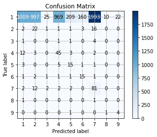

```python
probas = model_RNN.predict([val_input_begin, val_input_end, val_input_gene, val_input_variation])
pred_indices = np.argmax(probas, axis=1)
classes = np.array(range(1, 10))
preds = classes[pred_indices]
print('Log loss: {}'.format(log_loss(classes[np.argmax(val_output, axis=1)], probas)))
print('Accuracy: {}'.format(accuracy_score(classes[np.argmax(val_output, axis=1)], preds)))
skplt.plot_confusion_matrix(classes[np.argmax(val_output, axis=1)], preds)
```

```python
model_RNN.fit([
    np.concatenate([training_input_begin, val_input_begin]),
    np.concatenate([training_input_end,val_input_end]),
    np.concatenate([training_input_gene, val_input_gene]),
    np.concatenate([training_input_variation, val_input_variation])],
    np.concatenate([training_output,val_output]),
    epochs=3, batch_size=32, callbacks=[ckpt_callback])
```

```
WARNING:tensorflow:Can save best model only with val_loss available, skipping.
```

```
WARNING:tensorflow:Can save best model only with val_loss available, skipping.
```

```
WARNING:tensorflow:Can save best model only with val_loss available, skipping.
```

```
<keras.callbacks.History at 0x2f83e77c9a0>
```

```python
probas = model_RNN.predict([testing_input_begin, testing_input_end, testing_input_gene, testing_input_variation])
```

# Submission

```python
pred_lightgbm_cbow = pd.DataFrame(pred_lightgbm_cbow)
```

```python
pred_lightgbm_cbow
```

|  | 0 | 1 | 2 | 3 | 4 | 5 | 6 | 7 | 8 |
| --- | --- | --- | --- | --- | --- | --- | --- | --- | --- |
| 0 | 0.818595 | 0.005425 | 0.002759 | 0.047844 | 0.115482 | 0.006588 | 0.003164 | 0.000098 | 0.000044 |
| 1 | 0.117366 | 0.214578 | 0.000308 | 0.233388 | 0.024807 | 0.013292 | 0.393608 | 0.000441 | 0.002213 |
| 2 | 0.055681 | 0.155908 | 0.000339 | 0.510711 | 0.033401 | 0.027727 | 0.214088 | 0.001607 | 0.000537 |
| 3 | 0.087787 | 0.246559 | 0.002558 | 0.215700 | 0.006175 | 0.011131 | 0.423184 | 0.004564 | 0.002343 |
| 4 | 0.169930 | 0.389842 | 0.000114 | 0.221105 | 0.000457 | 0.003122 | 0.213530 | 0.001728 | 0.000173 |
| ... | ... | ... | ... | ... | ... | ... | ... | ... | ... |
| 981 | 0.653253 | 0.051785 | 0.001573 | 0.216084 | 0.022755 | 0.018283 | 0.016287 | 0.014709 | 0.005270 |
| 982 | 0.119158 | 0.083112 | 0.002390 | 0.023457 | 0.004074 | 0.006085 | 0.738405 | 0.021322 | 0.001997 |
| 983 | 0.222670 | 0.403995 | 0.010732 | 0.107920 | 0.006324 | 0.040786 | 0.188166 | 0.000261 | 0.019147 |
| 984 | 0.184898 | 0.033884 | 0.002271 | 0.407644 | 0.057376 | 0.016576 | 0.294994 | 0.001426 | 0.000930 |
| 985 | 0.191044 | 0.020541 | 0.002238 | 0.008609 | 0.004750 | 0.013081 | 0.751961 | 0.005216 | 0.002560 |

986 rows × 9 columns

```python
NEWsubmission_df1 = pred_lightgbm_cbow
NEWsubmission_df1.to_csv("NEWsubmission_lightGBM.csv",index=False)
```

```python
submission_df = pd.DataFrame(probas, columns=['class'+str(c+1) for c in range(9)])
submission_df['ID'] = test_full['ID']
submission_df
```

|  | class1 | class2 | class3 | class4 | class5 | class6 | class7 | class8 | class9 | ID |
| --- | --- | --- | --- | --- | --- | --- | --- | --- | --- | --- |
| 0 | 0.136310 | 0.149452 | 0.066428 | 0.175679 | 0.078828 | 0.111495 | 0.224416 | 0.028456 | 0.028936 | 1 |
| 1 | 0.149765 | 0.148731 | 0.069450 | 0.173661 | 0.075948 | 0.116260 | 0.205199 | 0.028706 | 0.032279 | 2 |
| 2 | 0.139460 | 0.152579 | 0.066211 | 0.177374 | 0.077043 | 0.110218 | 0.220301 | 0.028319 | 0.028495 | 3 |
| 3 | 0.137456 | 0.149471 | 0.065425 | 0.175648 | 0.073297 | 0.105749 | 0.237988 | 0.028614 | 0.026353 | 4 |
| 4 | 0.137762 | 0.148657 | 0.067419 | 0.174021 | 0.075813 | 0.113338 | 0.223093 | 0.028379 | 0.031518 | 5 |
| ... | ... | ... | ... | ... | ... | ... | ... | ... | ... | ... |
| 981 | 0.139212 | 0.150496 | 0.064653 | 0.174973 | 0.073532 | 0.105988 | 0.235834 | 0.028689 | 0.026623 | 982 |
| 982 | 0.138042 | 0.150908 | 0.064239 | 0.175431 | 0.073747 | 0.105197 | 0.237688 | 0.028702 | 0.026046 | 983 |
| 983 | 0.141906 | 0.152229 | 0.068569 | 0.174564 | 0.075118 | 0.110557 | 0.218752 | 0.028567 | 0.029738 | 984 |
| 984 | 0.137323 | 0.150333 | 0.064711 | 0.175940 | 0.074423 | 0.106625 | 0.235470 | 0.028533 | 0.026642 | 985 |
| 985 | 0.137411 | 0.150342 | 0.065198 | 0.175446 | 0.074903 | 0.107753 | 0.232890 | 0.028661 | 0.027394 | 986 |

986 rows × 10 columns

```python
submission_df.to_csv("NEWsubmission_RNN.csv",index=False)
```